# The Project

1. This is a project with minimal scaffolding. Expect to use the the discussion forums to gain insights! It’s not cheating to ask others for opinions or perspectives!
2. Be inquisitive, try out new things.
3. Use the previous modules for insights into how to complete the functions! You'll have to combine Pillow, OpenCV, and Pytesseract
4. There are hints provided in Coursera, feel free to explore the hints if needed. Each hint provide progressively more details on how to solve the issue. This project is intended to be comprehensive and difficult if you do it without the hints.

### The Assignment

Take a ZIP file) of images and process them, using a [library built into python](https://docs.python.org/3/library/zipfile.html) that you need to learn how to use. A ZIP file takes several different files and compresses them, thus saving space, into one single file. The files in the ZIP file we provide are newspaper images (like you saw in week 3). Your task is to write python code which allows one to search through the images looking for the occurrences of keywords and faces. E.g. if you search for "pizza" it will return a contact sheet of all of the faces which were located on the newspaper page which mentions "pizza". This will test your ability to learn a new ([library](https://docs.python.org/3/library/zipfile.html)), your ability to use OpenCV to detect faces, your ability to use tesseract to do optical character recognition, and your ability to use PIL to composite images together into contact sheets.

Each page of the newspapers is saved as a single PNG image in a file called images.zip. These newspapers are in english, and contain a variety of stories, advertisements and images. Note: This file is fairly large (~200 MB) and may take some time to work with, I would encourage you to use small_img.zip for testing.

Here's an example of the output expected. Using the small_img.zip file, if I search for the string "Christopher" I should see the following image:

[figure not shown]

If I were to use the images.zip file and search for "Mark" I should see the following image (note that there are times when there are no faces on a page, but a word is found!):

[figure not shown]

Note: That big file can take some time to process - for me it took nearly ten minutes! Use the small one for testing.

```python
import zipfile
import kraken
from kraken import pageseg
from PIL import Image
import pytesseract
import cv2 as cv
import numpy as np
from PIL import ImageDraw
from IPython.display import display
from numpy import asarray


#location of pytesseract
#pytesseract.pytesseract.tesseract_cmd = r"/home/ankit/anaconda3/envs/codingninja/bin/pytesseract"
# loading the face detection classifier
face_cascade = cv.CascadeClassifier('./readonly/haarcascade_frontalface_default.xml')
```

```python
def make_contact_list(faces_list):
    first_image = faces_list[0]
    if len(faces_list) > 5:
        img_height = 2
    else:
        img_height = 1
    contact_sheet=Image.new(first_image.mode, (first_image.width*5,first_image.height*img_height))

    x = 0
    y = 0

    for img in faces_list:
        # Lets paste the current image into the contact sheet
        contact_sheet.paste(img, (x, y) )
        # Now we update our X position. If it is going to be the width of the image, then we set it to 0
        # and update Y as well to point to the next "line" of the contact sheet.
        if x+first_image.width == contact_sheet.width:
            x=0
            y=y+first_image.height
        else:
            x=x+first_image.width

    return contact_sheet
```

```
Enter keyword to search for images : Mark
Result found in file a-0.png
```

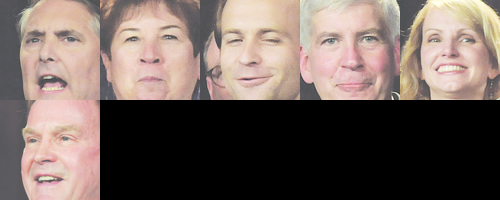

```
Result found in file a-1.png
```

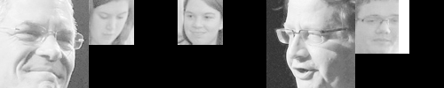

```
Result found in file a-10.png
But there were no faces in that file!
Result found in file a-13.png
```

```
Result found in file a-2.png
```

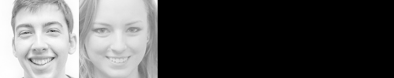

```
Result found in file a-3.png
```

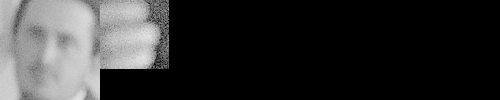

```
Result found in file a-8.png
But there were no faces in that file!
```

```python
def crop_faces(img, cv_img):
    faces = face_cascade.detectMultiScale(cv_img, 1.3, 5)   ## detecting faces
    faces_list = list()
    size = (100,100)
    for i in range(len(faces)):
        x,y,w,h =faces[i]
        face_img = img.crop((x, y, w+x, y+h))
        face_img.thumbnail(size)
        faces_list.append(face_img)

    return faces_list

def unzip_files(loc):
    fileloc = loc
    mydict = {}
    with zipfile.ZipFile(loc) as f:
        files = f.infolist()
        for file in files:
            with f.open(file) as imgfile:

                # Opening Image using PIL.Image
                img = Image.open(imgfile)
                img.save(file.filename)  # Saving image using PIL.Image
                # Opening image using CV
                cv_img = cv.imread(file.filename)    # RGB Pixel valued matrix

                mydict[file.filename] = [img, cv_img]


    return mydict

def extracting_lines_from_image(img):

    ##### Getting text from image
    gray = img.convert('1')
    return pytesseract.image_to_string(gray)


def make_dict(loc):
    mydict = unzip_files(loc)
    filenames = mydict.keys()
    for filename in filenames:
        img = mydict[filename][0]
        cv_img = mydict[filename][1]
        faces_list = crop_faces(img, cv_img) # Cropping Facing from image
        if len(faces_list) == 0:
            message = 'But there were no faces in that file!'
            mydict[filename].append(message)
        else:
            contact_sheet = make_contact_list(faces_list) # making contact sheet
            mydict[filename].append(contact_sheet)
        text = extracting_lines_from_image(img)
        mydict[filename].append(text)

    return mydict

def main(loc):
    keyword = input('Enter keyword to search for images : ')
    mydict = make_dict(loc)
    for key in mydict:
        text = mydict[key][3]
        if keyword in text:
            contact_sheet = mydict[key][2]
            print('Result found in file', key)
            if isinstance(contact_sheet, str):
                print(contact_sheet)
            else:
                display(contact_sheet)

main('./readonly/images.zip')                    ### result by Images.zip
```